# Regression

Nirzaree

31/08/2020

# Goal: Understand regression concepts with examples

## Rant/Why am I doing this

When I would read about regression, it would on one hand seem the simplest of approaches to try out and on the other hand, there are quite a bit of nuances in each of the steps to be well understood and applied. Also no one reference tackled all the relevant concepts. Many aspects would simple be ignored (mostly because they might not be applicable to the dataset), but if you had a new dataset, how would you know if you are missing something or doing something wrong? Obviously it took me waaay more than I thought it would, and it is quite long however I still think this would be my reference for all things linear regression going forward, and hopefully it would help some others too.

## Theory

- What is regression?  
  A technique applied to estimate a continuous output variable as a linear, additive function of one or more input variables.
- What types of regression techniques exist?
  1. Linear: $y = a_0 + a_1*x_1 + a_2*x_2 + a_3*x_3 + \epsilon$
     - Univariate: Only 1 input variable
     - Multivariate: More than 1 input variable
  2. Polynomial: $y = a_0 + a_1*x_1 + a_2*(x_1)^2 + a_3*(x_2) + a_4*(x_2)^2 + a_5*x_1*x_2 + \epsilon$
  3. Logistic: $log(p_i/(1-p_i)) = a_0 + a_1*x_1 + a_2*x_2 + a_3*x_3 + \epsilon$
- Assumptions of linear regression When we apply linear regression to a dataset, we assume that:
  1. There is a linear (& additive in case of more than 1 input variables) relationship between the inputs and the output variables
  2. There is constant variance in the error term
  3. The error term is normally distributed
  4. The errors terms are independent. **
  5. In case of multilinear regression, there is no collinearity between the input terms.
- Preprocessing for linear regression
- Feature Engineering for linear regression
- Tuning a regression model
- Metrics for evaluating a linear regression model
1. Statistical significance of the model:
- **p-value** : p-value is the probability that random chance generated the results or something that is equal or rare.
  - p-value of individual predictor variables:
  - p-value of the entire model:
  - A model can be considered statistically significant only if both these p-values are < pre-determined statistical significance threshold (0.05)
  - In r, this is visually represented by the number of stars at the end of the row. The more the stars besides the p-value of the variable, the more significant the variable.
- **t-value** : t-value can be interpreted as the higher the t-value, the lower the chance that the coefficients are non-zero by chance.
  - Pr(>|t|) indicates the probability that you get t-value as high or higher than the one observed given null hypothesis is true. So if Pr(>|t|) is lower, then the coefficients are significant and vice versa.
    - $t-value = Coefficient/Standard Error$
    - $p-value = 2 * pt(q = -abs(t-value),df = (nrow - ncol))$  
      where pt = distribution function for the t-distribution with df degrees of freedom and q = vector of quantiles [3]
2. Model Accuracy:
- The actual amount of information in a dataset is indicated by the amount of variance it contains. $R^2$ tells us the amount of variance of the data that is explained by the model. [3]
  - $R^2 = 1 - (SSE/SST)$  
    where Sum of Squared Error or $SSE = \sum\limits_{i = 1}^{n}(y_i - \hat{y_i})^2$ &  
    Total Sum of Squares or $SST = \sum\limits_{i = 1}^n(y_i - \bar{y})^2$ where  
    $\hat{y_i}$ = predicted value when actual observation = $y_i$ & $\bar{y_i}$ = mean value of all output values

  [Nicely explained stepwise $R^2$ computation on a dataset](https://internal.ncl.ac.uk/ask/numeracy-maths-statistics/statistics/regression-and-correlation/coefficient-of-determination-r-squared.html)
- Adjusted $R^2$: As you add variables to the model, the value of $R^2$ will always increase, independent of whether the additional variables are significant to the model or not. Hence, we use $R^2$ Adjusted.
  - Adjusted $R^2 = 1 - MSE/MST$  
    where $MSE (Mean Squared Error) = SSE/(n - q)$ & $MST = SST/(n-1)$  
    where $n = total number observations$ & $q = total number of coefficients$  
    Thus Adjusted $R^2$ penalizes higher number of predictors in the model.
- Low value of $R^2$ not always bad
  - Certain types of problems to always have lower $R^2$ as outputs are just harder to predict [5]
  - However, if there are predictors which are statistically significant, then they can still be insightful. The model might not be good to do precise predictions.
- High value of $R^2$ not always good [5]

```r
x = seq(1:100)
y = x^2

linModelxy <- lm(y~x)
summary(linModelxy)
```

```
##
## Call:
## lm(formula = y ~ x)
##
## Residuals:
##    Min     1Q Median     3Q    Max
##   -833   -677   -208    573   1617
##
## Coefficients:
##              Estimate Std. Error t value Pr(>|t|)
## (Intercept) -1717.000    151.683  -11.32   <2e-16 ***
## x             101.000      2.608   38.73   <2e-16 ***
## ---
## Signif. codes:  0 '***' 0.001 '**' 0.01 '*' 0.05 '.' 0.1 ' ' 1
##
## Residual standard error: 752.7 on 98 degrees of freedom
## Multiple R-squared:  0.9387, Adjusted R-squared:  0.9381
## F-statistic:  1500 on 1 and 98 DF,  p-value: < 2.2e-16
```

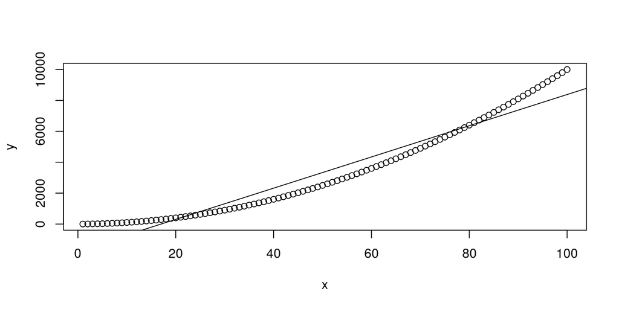

```
## integer(0)
```

```r
plot(x = x, y = y) + abline(linModelxy)
```

**Observations** Always look at the $R^2$ values in conjunction with other metrics, residual plots and domain knowledge.

- F-test: $R^2$ does not provide a formal hypothesis test for relationship between the predicted and the actual value if the response variable. Enter **F-test**

## Intuitive Approach

Intuitively we would do the following (with no theory knowhow on feature engineering,validation of model etc)

1. Load the dataset & check if there are features that correlate significantly and linearly (well we can transform the input data and it has its nuances but for now we just try to see what best fits the data as it is) the output/response variable
2. Build a model with all variables
3. Check for important variables
4. Reduce the model to include only the significant variables
5. Check how good the model is:
6. If it is good enough, use it to make predictions

## MTCars Dataset

```
Dataset description: mtcars
The data was extracted from the 1974 Motor Trend US magazine, and comprises fuel consumption and 10 aspects of automobile design and performance for 32 automobiles (1973–74 models).

Format:
A data frame with 32 observations on 11 (numeric) variables.

[, 1]   mpg Miles/(US) gallon
[, 2]   cyl Number of cylinders
[, 3]   disp    Displacement (cu.in.)
[, 4]   hp  Gross horsepower
[, 5]   drat    Rear axle ratio
[, 6]   wt  Weight (1000 lbs)
[, 7]   qsec    1/4 mile time
[, 8]   vs  Engine (0 = V-shaped, 1 = straight)
[, 9]   am  Transmission (0 = automatic, 1 = manual)
[,10]   gear    Number of forward gears
[,11]   carb    Number of carburetors

Task: Regression analysis of fuel efficiency
```

### 1. Load Data

```r
dtMTCars <- data.table(mtcars)
head(dtMTCars)
```

```
##     mpg cyl disp  hp drat    wt  qsec vs am gear carb
## 1: 21.0   6  160 110 3.90 2.620 16.46  0  1    4    4
## 2: 21.0   6  160 110 3.90 2.875 17.02  0  1    4    4
## 3: 22.8   4  108  93 3.85 2.320 18.61  1  1    4    1
## 4: 21.4   6  258 110 3.08 3.215 19.44  1  0    3    1
## 5: 18.7   8  360 175 3.15 3.440 17.02  0  0    3    2
## 6: 18.1   6  225 105 2.76 3.460 20.22  1  0    3    1
```

```r
summary(dtMTCars)
```

```
##       mpg             cyl             disp             hp
##  Min.   :10.40   Min.   :4.000   Min.   : 71.1   Min.   : 52.0
##  1st Qu.:15.43   1st Qu.:4.000   1st Qu.:120.8   1st Qu.: 96.5
##  Median :19.20   Median :6.000   Median :196.3   Median :123.0
##  Mean   :20.09   Mean   :6.188   Mean   :230.7   Mean   :146.7
##  3rd Qu.:22.80   3rd Qu.:8.000   3rd Qu.:326.0   3rd Qu.:180.0
##  Max.   :33.90   Max.   :8.000   Max.   :472.0   Max.   :335.0
##       drat             wt             qsec             vs
##  Min.   :2.760   Min.   :1.513   Min.   :14.50   Min.   :0.0000
##  1st Qu.:3.080   1st Qu.:2.581   1st Qu.:16.89   1st Qu.:0.0000
##  Median :3.695   Median :3.325   Median :17.71   Median :0.0000
##  Mean   :3.597   Mean   :3.217   Mean   :17.85   Mean   :0.4375
##  3rd Qu.:3.920   3rd Qu.:3.610   3rd Qu.:18.90   3rd Qu.:1.0000
##  Max.   :4.930   Max.   :5.424   Max.   :22.90   Max.   :1.0000
##        am              gear            carb
##  Min.   :0.0000   Min.   :3.000   Min.   :1.000
##  1st Qu.:0.0000   1st Qu.:3.000   1st Qu.:2.000
##  Median :0.0000   Median :4.000   Median :2.000
##  Mean   :0.4062   Mean   :3.688   Mean   :2.812
##  3rd Qu.:1.0000   3rd Qu.:4.000   3rd Qu.:4.000
##  Max.   :1.0000   Max.   :5.000   Max.   :8.000
```

**High level summary**

- Predictor variables: 10
  - Numeric variables: 8
  - Categorical variables: 2 (Engine (0 = V-shaped, 1 = straight) & Transmission (0 = automatic, 1 = manual))
- Response variable: mpg Miles/(US) gallon

### 2. Feature Exploration

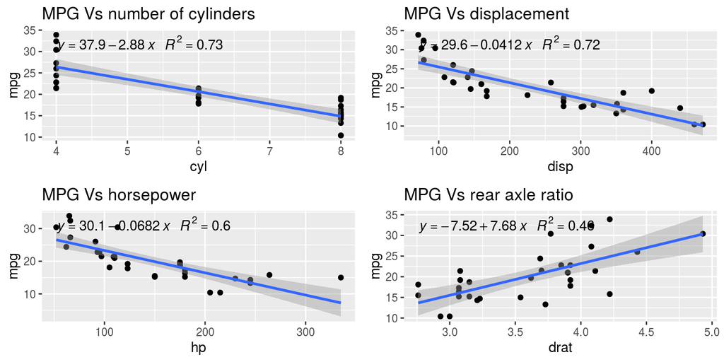

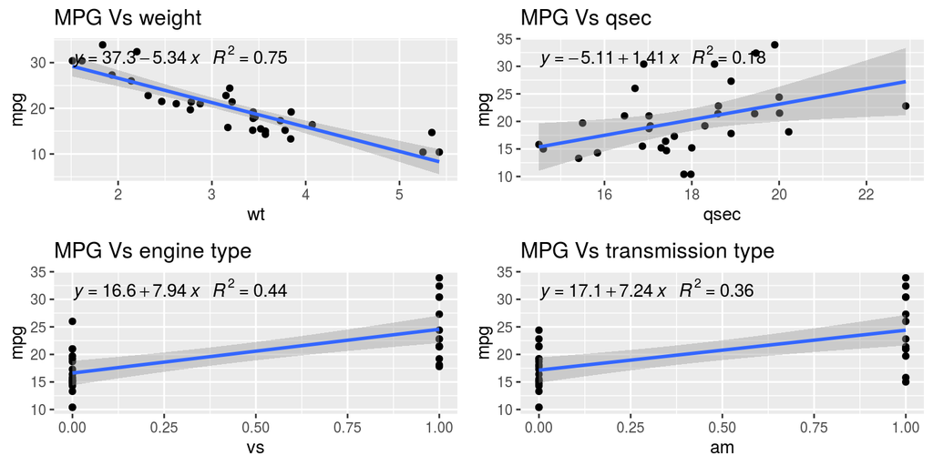

[figure not shown]

### 3. Build model: a) Simple linear regression with all variables

We now build a model using all variables and we check how it looks.

```r
MultLinearModel <- lm(mpg~.,data = dtMTCars)
summary(MultLinearModel)
```

```
##
## Call:
## lm(formula = mpg ~ ., data = dtMTCars)
##
## Residuals:
##     Min      1Q  Median      3Q     Max
## -3.4506 -1.6044 -0.1196  1.2193  4.6271
##
## Coefficients:
##             Estimate Std. Error t value Pr(>|t|)
## (Intercept) 12.30337   18.71788   0.657   0.5181
## cyl         -0.11144    1.04502  -0.107   0.9161
## disp         0.01334    0.01786   0.747   0.4635
## hp          -0.02148    0.02177  -0.987   0.3350
## drat         0.78711    1.63537   0.481   0.6353
## wt          -3.71530    1.89441  -1.961   0.0633 .
## qsec         0.82104    0.73084   1.123   0.2739
## vs           0.31776    2.10451   0.151   0.8814
## am           2.52023    2.05665   1.225   0.2340
## gear         0.65541    1.49326   0.439   0.6652
## carb        -0.19942    0.82875  -0.241   0.8122
## ---
## Signif. codes:  0 '***' 0.001 '**' 0.01 '*' 0.05 '.' 0.1 ' ' 1
##
## Residual standard error: 2.65 on 21 degrees of freedom
## Multiple R-squared:  0.869,  Adjusted R-squared:  0.8066
## F-statistic: 13.93 on 10 and 21 DF,  p-value: 3.793e-07
```

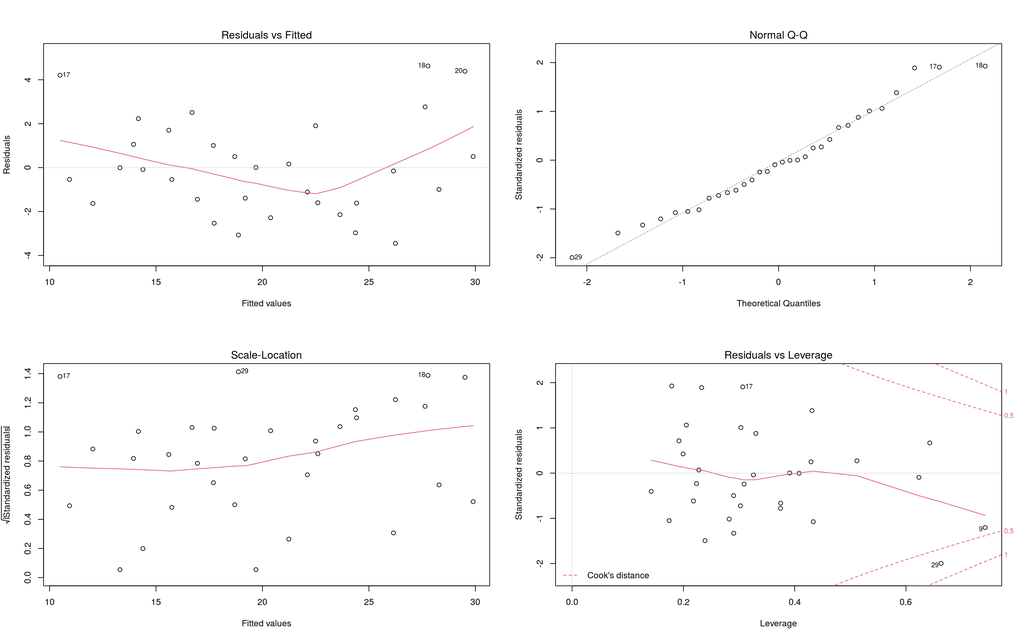

```r
par(mfrow=c(2,2))
plot(MultLinearModel)
```

**Observations:** Score: R2 adjusted is 80.66% which is decent. Assumptions are fairly satisfied. However, none of the variables seem to be very statistically significant, hence we need to reduce the variables and try fitting the model again.

### 3. Build model: b) Simple linear regression with few handpicked variables

We now build a model using a few variables that we would assume would have a fairly strong correlation with mileage. (todo: how to formally check for collinearity between the variables?)

- Weight: As the weight of the car increases, mileage would decrease.
- Transmission type: Milege of Manual > Automatic.
- Horse power: As horse power of the car increases, mileage would decrease.
- Engine displacement: Engine displacement and horse power are quite related,so we can check which one of this helps the model better.

```r
MultLinearModel1 <- lm(mpg~wt+am+hp,data = dtMTCars)
summary(MultLinearModel1)
```

```
##
## Call:
## lm(formula = mpg ~ wt + am + hp, data = dtMTCars)
##
## Residuals:
##     Min      1Q  Median      3Q     Max
## -3.4221 -1.7924 -0.3788  1.2249  5.5317
##
## Coefficients:
##              Estimate Std. Error t value Pr(>|t|)
## (Intercept) 34.002875   2.642659  12.867 2.82e-13 ***
## wt          -2.878575   0.904971  -3.181 0.003574 **
## am           2.083710   1.376420   1.514 0.141268
## hp          -0.037479   0.009605  -3.902 0.000546 ***
## ---
## Signif. codes:  0 '***' 0.001 '**' 0.01 '*' 0.05 '.' 0.1 ' ' 1
##
## Residual standard error: 2.538 on 28 degrees of freedom
## Multiple R-squared:  0.8399, Adjusted R-squared:  0.8227
## F-statistic: 48.96 on 3 and 28 DF,  p-value: 2.908e-11
```

```r
MultLinearModel2 <- lm(mpg~wt+am+disp,data = dtMTCars)
summary(MultLinearModel2)
```

```
##
## Call:
## lm(formula = mpg ~ wt + am + disp, data = dtMTCars)
##
## Residuals:
##     Min      1Q  Median      3Q     Max
## -3.4890 -2.4106 -0.7232  1.7503  6.3293
##
## Coefficients:
##              Estimate Std. Error t value Pr(>|t|)
## (Intercept) 34.675911   3.240609  10.700 2.12e-11 ***
## wt          -3.279044   1.327509  -2.470   0.0199 *
## am           0.177724   1.484316   0.120   0.9055
## disp        -0.017805   0.009375  -1.899   0.0679 .
## ---
## Signif. codes:  0 '***' 0.001 '**' 0.01 '*' 0.05 '.' 0.1 ' ' 1
##
## Residual standard error: 2.967 on 28 degrees of freedom
## Multiple R-squared:  0.781,  Adjusted R-squared:  0.7576
## F-statistic: 33.29 on 3 and 28 DF,  p-value: 2.25e-09
```

```r
MultLinearModelHandpicked <- lm(mpg~wt+hp,data = dtMTCars)
summary(MultLinearModelHandpicked)
```

```
##
## Call:
## lm(formula = mpg ~ wt + hp, data = dtMTCars)
##
## Residuals:
##    Min     1Q Median     3Q    Max
## -3.941 -1.600 -0.182  1.050  5.854
##
## Coefficients:
##             Estimate Std. Error t value Pr(>|t|)
## (Intercept) 37.22727    1.59879  23.285  < 2e-16 ***
## wt          -3.87783    0.63273  -6.129 1.12e-06 ***
## hp          -0.03177    0.00903  -3.519  0.00145 **
## ---
## Signif. codes:  0 '***' 0.001 '**' 0.01 '*' 0.05 '.' 0.1 ' ' 1
##
## Residual standard error: 2.593 on 29 degrees of freedom
## Multiple R-squared:  0.8268, Adjusted R-squared:  0.8148
## F-statistic: 69.21 on 2 and 29 DF,  p-value: 9.109e-12
```

**Observations** * Coefficients: * Weight: MPG decreases by ~3.87 units per unit increase in weight in the given dataset. * hp: MPG decreases by ~0.03 units per unit increase in weight.

- R2 adjusted: 81.48% slightly better than the model with all variables. Why so? Because that model was not able to remove variables. Now we let it do that. We try stepwise linear regression.

### 3. Build model: c) Stepwise linear regression

```r
LinModelStep <- step(lm(mpg~.,dtMTCars),direction = "both")
```

```
## Start:  AIC=70.9
## mpg ~ cyl + disp + hp + drat + wt + qsec + vs + am + gear + carb
##
##        Df Sum of Sq    RSS    AIC
## - cyl   1    0.0799 147.57 68.915
## - vs    1    0.1601 147.66 68.932
## - carb  1    0.4067 147.90 68.986
## - gear  1    1.3531 148.85 69.190
## - drat  1    1.6270 149.12 69.249
## - disp  1    3.9167 151.41 69.736
## - hp    1    6.8399 154.33 70.348
## - qsec  1    8.8641 156.36 70.765
## <none>              147.49 70.898
## - am    1   10.5467 158.04 71.108
## - wt    1   27.0144 174.51 74.280
##
## Step:  AIC=68.92
## mpg ~ disp + hp + drat + wt + qsec + vs + am + gear + carb
##
##        Df Sum of Sq    RSS    AIC
## - vs    1    0.2685 147.84 66.973
## - carb  1    0.5201 148.09 67.028
## - gear  1    1.8211 149.40 67.308
## - drat  1    1.9826 149.56 67.342
## - disp  1    3.9009 151.47 67.750
## - hp    1    7.3632 154.94 68.473
## <none>              147.57 68.915
## - qsec  1   10.0933 157.67 69.032
## - am    1   11.8359 159.41 69.384
## + cyl   1    0.0799 147.49 70.898
## - wt    1   27.0280 174.60 72.297
##
## Step:  AIC=66.97
## mpg ~ disp + hp + drat + wt + qsec + am + gear + carb
##
##        Df Sum of Sq    RSS    AIC
## - carb  1    0.6855 148.53 65.121
## - gear  1    2.1437 149.99 65.434
## - drat  1    2.2139 150.06 65.449
## - disp  1    3.6467 151.49 65.753
```

[output cut: 72 more lines]

```
## Step:  AIC=61.31
## mpg ~ wt + qsec + am
##
##        Df Sum of Sq    RSS    AIC
## <none>              169.29 61.307
## + hp    1     9.219 160.07 61.515
## + carb  1     8.036 161.25 61.751
## + disp  1     3.276 166.01 62.682
## + cyl   1     1.501 167.78 63.022
## + drat  1     1.400 167.89 63.042
## + gear  1     0.123 169.16 63.284
## + vs    1     0.000 169.29 63.307
## - am    1    26.178 195.46 63.908
## - qsec  1   109.034 278.32 75.217
## - wt    1   183.347 352.63 82.790
```

```r
summary(LinModelStep)
```

```
##
## Call:
## lm(formula = mpg ~ wt + qsec + am, data = dtMTCars)
##
## Residuals:
##     Min      1Q  Median      3Q     Max
## -3.4811 -1.5555 -0.7257  1.4110  4.6610
##
## Coefficients:
##             Estimate Std. Error t value Pr(>|t|)
## (Intercept)   9.6178     6.9596   1.382 0.177915
## wt           -3.9165     0.7112  -5.507 6.95e-06 ***
## qsec          1.2259     0.2887   4.247 0.000216 ***
## am            2.9358     1.4109   2.081 0.046716 *
## ---
## Signif. codes:  0 '***' 0.001 '**' 0.01 '*' 0.05 '.' 0.1 ' ' 1
##
## Residual standard error: 2.459 on 28 degrees of freedom
## Multiple R-squared:  0.8497, Adjusted R-squared:  0.8336
## F-statistic: 52.75 on 3 and 28 DF,  p-value: 1.21e-11
```

**Observations** * Features it chose: * Weight: expected & relevant * type of transmission: expected and relevant * qsec: time taken (in seconds) by the car to cover quarter mile. In some ways related to the car power, the more the power, the lesser the time taken, the lesser the mileage. So this feature is directly proportional to the mpg, however the feature plot of qsec vs mpg alone does not look very good. Since the $R^2$ between the handpicked model and the step model does not differ a lot, we can keep the handpicked model as the final candidate, however any of the two models should be fine.

### 4. Validate best model

We now check if linear regression assumptions are validated by the final model that we chose.

[figure not shown]

**Observations:** Linear Regression assumptions: 1. Linearity: 2. Constant error variance (homoscedasticity) 3. Independent error terms (this is difficult to identify through simple plots, so we leave it aside for now) 4. Normal errors

1. Residuals Vs fitted:
- No pattern in residuals vs fitted values. In a linear regression, sum of residuals would be 0. There would be no pattern in the error terms and the points should just be a random cloud of points => Constant variance assumption met
- Red line is almost horizontal (not great but not too bad) => linearity assumption met
2. Q-Q plot: Follow the line for the most part => normally distributed error terms assumption met

Other plots that help in identifying non-linearity, non constant variance and other problematic observations, but we chill on that for now.

3. Variance in residuals: Fairly flat line hence variance is reasonably constant across predictor range (homoscedasticity)
4. Cooke’s distance : for the 3 higher points is < 0.5. Threshold Generally: 4/N or 4/(n - k -1) where k = number of explanatory variables & N = number of observations. Need to check about how much cooke’s distance is bad, with respect to the given problem.

### 5. Summary

- We took dataset with multiple explanatory variables and one response variable of interest.
- We applied a linear model using all variables. It fairly satisfied the assumptions however seemed to have too many variables in it, which might not be required.
- We then tried the model with a few variables which seemed to have linear relation with the output variable, and the model had slightly better R2 than the model with all the variables, suggesting further that all variables are not required.
- We finally employed stepwise linear regression model which has the capability of removing unnecessary variables. It had sligtly better R2 than both the earlier models.
- We then checked if the assumptions of linearity, constant error variance, normal distribution of errors are satisfied by the final (step wise linear) model and they were fairly satisfied.
- What is not been covered in this notebook is how to handle collinearity between features, how to find the best linear model, any pre-processing requirements for linear model.

## References

1.Fuel Efficiency Regression Analysis [Regression analysis of fuel efficiency using R dataset mtcars](https://rstudio-pubs-static.s3.amazonaws.com/157017_d791d59b482441d386ce8b31b3337ecf.html)  
2. Validating linear regression assumptions using diagnostics plots [Checking Linear Regression Assumptions in R | R Tutorial 5.2 | MarinStatsLectures](https://www.youtube.com/watch?v=eTZ4VUZHzxw)  
3. Linear Regression Evaluation Metrics Nicely Explained [Linear Regression](http://r-statistics.co/Linear-Regression.html)  
4. Nicely explained stepwise $R^2$ computation on a dataset [Coefficient of Determination, R-squared](https://internal.ncl.ac.uk/ask/numeracy-maths-statistics/statistics/regression-and-correlation/coefficient-of-determination-r-squared.html)  
5. Nice interpretation of $R^2$ values: [Regression Analysis: How Do I Interpret R-squared and Assess the Goodness-of-Fit?](https://blog.minitab.com/blog/adventures-in-statistics-2/regression-analysis-how-do-i-interpret-r-squared-and-assess-the-goodness-of-fit)

## notes to self

1. new package for plotting equation in feature plots
- library: ggpmisc
- function: stat_poly_eq

## ToDo / ToAnswer

- p-value: how is it computed?
- p-value: Why is threshold 0.05?
- Whats the required threshold for Pr(> |t|) for significance?
- Understand results of cv
- Understand params in cross validation folds, iterations
- How to detect and handle collinearity between features
- Feature selection
- How to find the best fit model
- Show with examples problematic models, how to detect them etc
  - Anscombe’s quartet
- Does regularization apply in regression?
- Is it possible to have high $R^2$ without having any predictors that are individually statistically significant? Somewhat similar to whats happening when the MTCars data is run with a model using all variables. What do you understand about such a case? Also vice versa, strongly significant variables but still low $R^2$ value. What would that mean?
- To read: [Is R-squared Useless?](https://data.library.virginia.edu/is-r-squared-useless/)
- More mind numbing metrics: F-statistic, AIC, BIC. Examples of how they save then $R^2$ misleads. When do these new metrics fail? What is the final take on metrics?
- F1 score
- AIC
- glm
- Other regression techniques
  - ridge
  - lasso
  - elastic net
- Quick rundown on 2-3 more datasets